# ALY6040 M1 Technique Practice - EDA

Instructor: Dr. Marcus Ellis

Student: Shahabaddin Feghahati

Completion Date: 3/3/2023

```r
library(ggplot2)
library(magrittr)
library(kableExtra)
library(GGally)
library(tidyr)
library(tidyverse)
library(repr)
library(gridExtra)
```

#### Introduction

The report analyzes the diamonds dataset using R programming language and several data visualization techniques. The dataset contains information on the prices and attributes of almost 54,000 diamonds. The diamond dataset has become a resource for conducting data analysis and machine learning to answer a diverse range of questions (GGPLOT2 / R / data.R, 2022). With the help of this dataset, our aim in performing exploratory data analysis is to pinpoint the major factors that affect diamond prices and gain a deeper understanding of how diamond prices are distributed.

The report begins by cleaning the data and removing duplicates. Next, it summarizes the dataset and creates several plots, including scatterplot matrix, boxplots, and histograms, to explore the relationships between different variables in the dataset. Finally, it analyzes the relationship between the diamond prices and different attributes such as cut, color, and clarity.

#### Analysis

```r
# Access Diamonds dataset
data(diamonds)

# View the first few rows of the dataset
head(diamonds)
```

```
## # A tibble: 6 × 10
##   carat cut       color clarity depth table price     x     y     z
##   <dbl> <ord>     <ord> <ord>   <dbl> <dbl> <int> <dbl> <dbl> <dbl>
## 1  0.23 Ideal     E     SI2      61.5    55   326  3.95  3.98  2.43
## 2  0.21 Premium   E     SI1      59.8    61   326  3.89  3.84  2.31
## 3  0.23 Good      E     VS1      56.9    65   327  4.05  4.07  2.31
## 4  0.29 Premium   I     VS2      62.4    58   334  4.2   4.23  2.63
## 5  0.31 Good      J     SI2      63.3    58   335  4.34  4.35  2.75
## 6  0.24 Very Good J     VVS2     62.8    57   336  3.94  3.96  2.48
```

Observing the head of the diamonds dataset shows that it contains information about diamonds, including weight, cut quality, color, clarity, dimensions, and price. It has 53,940 rows and 10 columns, with ordinal factors and numeric values.

Explore the structure of the dataset

```r
str(diamonds)
```

```
## tibble [53,940 × 10] (S3: tbl_df/tbl/data.frame)
##  $ carat  : num [1:53940] 0.23 0.21 0.23 0.29 0.31 0.24 0.24 0.26 0.22 0.23 ...
##  $ cut    : Ord.factor w/ 5 levels "Fair"<"Good"<..: 5 4 2 4 2 3 3 3 1 3 ...
##  $ color  : Ord.factor w/ 7 levels "D"<"E"<"F"<"G"<..: 2 2 2 6 7 7 6 5 2 5 ...
##  $ clarity: Ord.factor w/ 8 levels "I1"<"SI2"<"SI1"<..: 2 3 5 4 2 6 7 3 4 5 ...
##  $ depth  : num [1:53940] 61.5 59.8 56.9 62.4 63.3 62.8 62.3 61.9 65.1 59.4 ...
##  $ table  : num [1:53940] 55 61 65 58 58 57 57 55 61 61 ...
##  $ price  : int [1:53940] 326 326 327 334 335 336 336 337 337 338 ...
##  $ x      : num [1:53940] 3.95 3.89 4.05 4.2 4.34 3.94 3.95 4.07 3.87 4 ...
##  $ y      : num [1:53940] 3.98 3.84 4.07 4.23 4.35 3.96 3.98 4.11 3.78 4.05 ...
##  $ z      : num [1:53940] 2.43 2.31 2.31 2.63 2.75 2.48 2.47 2.53 2.49 2.39 ...
```

The data contains diamonds’ weight, cut quality, color, clarity, dimensions, and prices. It has 53,940 rows and 10 columns. The data set contains various data types, including numeric, ordinal factor, and integer vectors. Numeric vectors are used to represent continuous data such as weight and dimensions. Ordinal factor vectors are used to represent categorical data with a defined order such as cut quality, color, and clarity. Integer vectors are used to represent discrete numerical data such as diamond prices.

Find duplicates in the diamond dataset

```r
# Find duplicates
dupes <- diamonds[duplicated(diamonds), ]

# Print duplicates
print(dupes)
```

```
## # A tibble: 146 × 10
##    carat cut       color clarity depth table price     x     y     z
##    <dbl> <ord>     <ord> <ord>   <dbl> <dbl> <int> <dbl> <dbl> <dbl>
##  1  0.79 Ideal     G     SI1      62.3    57  2898  5.9   5.85  3.66
##  2  0.79 Ideal     G     SI1      62.3    57  2898  5.9   5.85  3.66
##  3  0.79 Ideal     G     SI1      62.3    57  2898  5.9   5.85  3.66
##  4  0.79 Ideal     G     SI1      62.3    57  2898  5.9   5.85  3.66
##  5  1.52 Good      E     I1       57.3    58  3105  7.53  7.42  4.28
##  6  1    Fair      E     SI2      67      53  3136  6.19  6.13  4.13
##  7  1    Fair      F     SI2      65.1    55  3265  6.26  6.23  4.07
##  8  0.9  Very Good I     VS2      58.4    62  3334  6.29  6.35  3.69
##  9  1    Ideal     E     SI2      62.9    56  3450  6.32  6.3   3.97
## 10  1    Fair      H     SI1      65.5    57  3511  6.26  6.21  4.08
## # … with 136 more rows
```

```r
# Compare the duplicated observations
#dupes %>% summarytools::descr() %>% round(2) %>% knitr::kable(align = "c") %>% kable_classic(c("striped", "hover"), font_size = 16)
```

The common strategies for dealing with duplicates in a dataset are:

Remove duplicates: If the duplicates are not providing any new or useful information, you can remove them from the dataset using the unique() function in R.

Keep only one copy of the duplicates: If the duplicates are providing some new or useful information, you can keep only one copy of them in the dataset using the duplicated() function in R.

Investigate the duplicates: If the duplicates are unexpected or indicate an issue with the data collection process, you can investigate them further by examining the duplicates and trying to determine the cause of the duplication.

Choosing a strategy for dealing with duplicates depends on the nature of the data and the analysis you are planning to perform.

```r
# Keep only one copy of the duplicates in the diamond dataset
diamonds <- diamonds[!duplicated(diamonds), ]
```

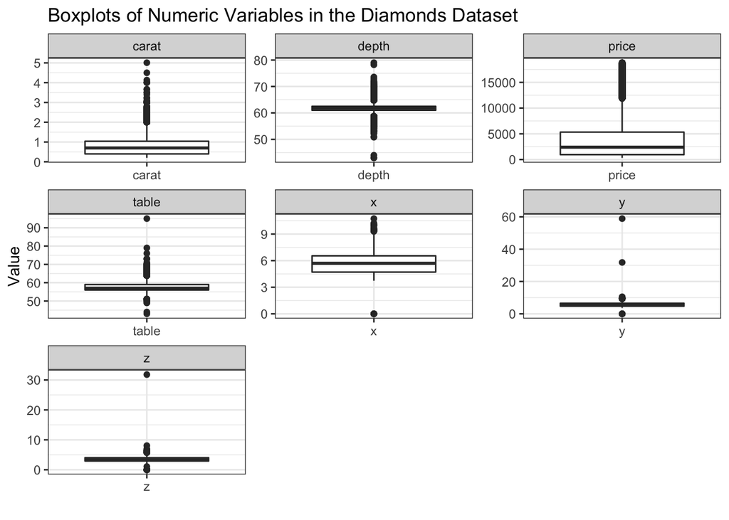

```r
# Select the numeric variables
numeric_vars <- diamonds[, sapply(diamonds, is.numeric)]

# Reshape the data into a long format
diamonds_long <- gather(data = numeric_vars, key = "variable", value = "value")

# Create a boxplot with a logarithmic y-axis
bp <- ggplot(diamonds_long, aes(x = variable, y = value)) +
  geom_boxplot() +
#  scale_y_log10() +
#  labs(y = "Value (log scale)", x = "") +
  labs(y = "Value", x = "") +
  ggtitle("Boxplots of Numeric Variables in the Diamonds Dataset") +
  theme_bw()

# Create a grid of boxplots using facet_wrap()
bp + facet_wrap(~ variable, scales = "free")
```

The plot shows a series of boxplots for the numeric variables in the Diamonds dataset. Each boxplot displays the distribution of a single variable, with the variable name displayed on the x-axis and the value displayed on a y-axis. The box extends from the lower to upper quartile values of the data, with a line indicating the median value. Whiskers extend from the box to show the range of the data, with outliers plotted as individual points. The presence of outliers can have a significant impact on the analysis of the data and may need to be addressed during the data preprocessing stage or during subsequent statistical analysis.

To identify any suspicious data in the Diamonds dataset from ggplot2 in R, one approach is to create a scatter plot matrix using the ggpairs() function from the GGally package. This will allow us to visualize the pairwise relationships between the numeric variables in the dataset and identify any unusual patterns or outliers.

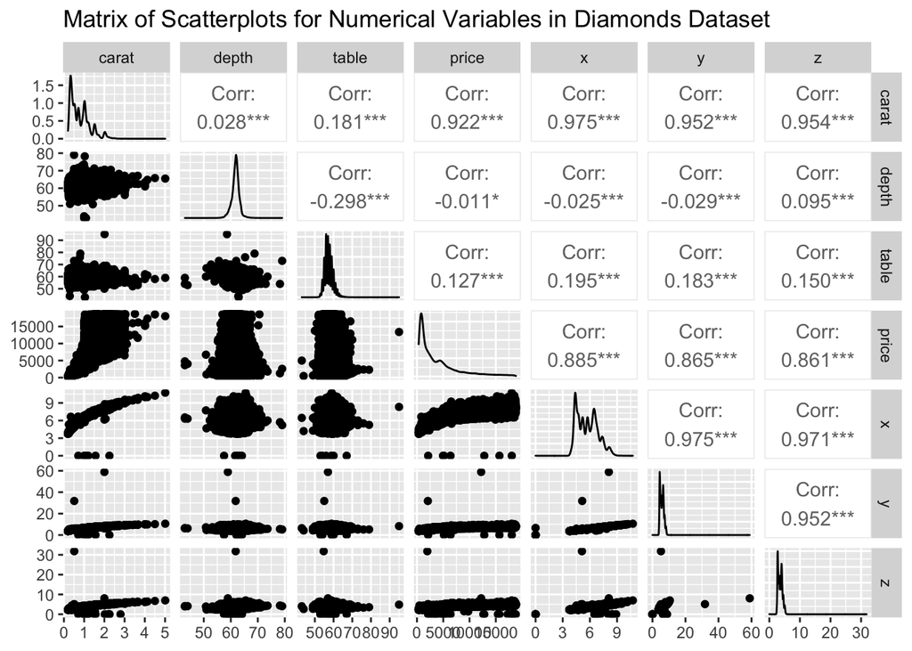

```r
diamonds_numeric <- diamonds[, c("carat", "depth", "table", "price", "x", "y", "z")]

# create scatterplot matrix for the data
ggpairs(diamonds_numeric, axisLabels = "show", progress = FALSE, alpha = 0.1, size = 0.5, alphaBlending = TRUE) +
    ggtitle("Matrix of Scatterplots for Numerical Variables in Diamonds Dataset")
```

The scatter plots in the matrix seem to be too tightly packed, making it difficult to interpret the data. One possible solution to this issue is to subset the data. If the overplotting is a result of having too many data points, you may want to consider selecting a smaller sample size. This can help to reduce the number of points in the scatterplots and make it easier to identify patterns in the data.

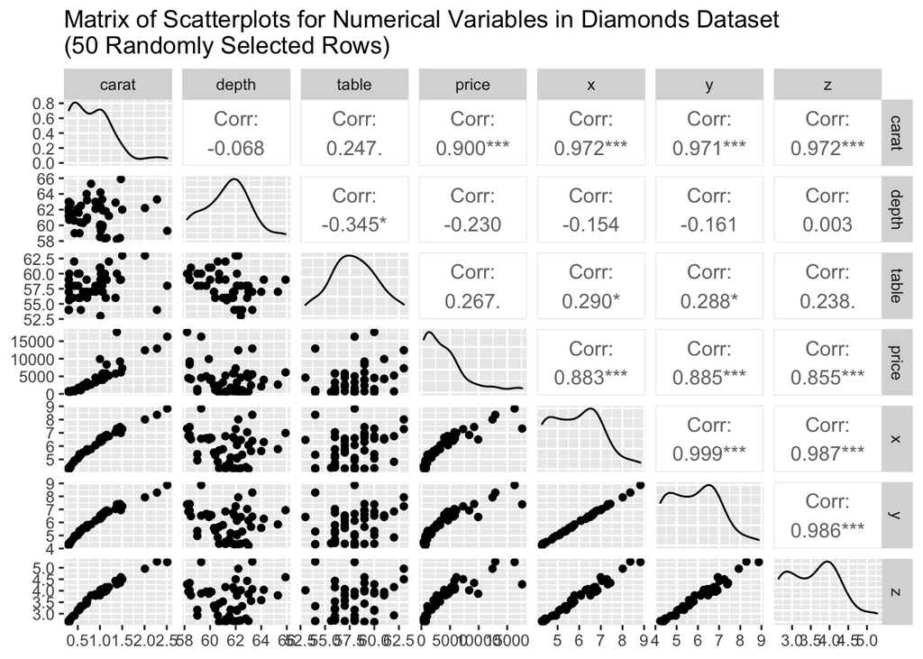

```r
diamonds_numeric <- diamonds[, c("carat", "depth", "table", "price", "x", "y", "z")]

# randomly sample 50 rows from the diamonds_numeric dataset
set.seed(123) # for reproducibility
diamonds_numeric_sub <- diamonds_numeric[sample(nrow(diamonds_numeric), 50), ]

# create scatterplot matrix for the subsetted data
ggpairs(diamonds_numeric_sub, axisLabels = "show", progress = FALSE) +
  ggtitle("Matrix of Scatterplots for Numerical Variables in Diamonds Dataset\n(50 Randomly Selected Rows)")
```

The code above generates a matrix of scatterplots for the numerical variables (carat, depth, table, price, x, y, and z) in the diamonds dataset.

The scatterplots can be used to explore the pairwise relationships between the variables. For example, you can look for patterns or trends in the data, such as positive or negative correlations between variables. You can also look for outliers or unusual observations in the data.

The correlation matrix of the numerical variables in the diamonds dataset shows the Pearson correlation coefficients between each pair of variables. The matrix indicates that carat has a strong positive correlation with price, suggesting that the weight of the diamond is a major factor in determining its cost. The dimensions of the diamond (x, y, and z) are strongly positively correlated with each other, as expected since they are measures of the size of the diamond. Depth is weakly negatively correlated with price, and table is weakly positively correlated with price, suggesting that these variables may have less influence on the price of the diamond. Carat is also weakly positively correlated with table, indicating that larger diamonds may have slightly wider tables. However, it’s important to remember that correlation does not imply causation, and further analysis is needed to establish causal relationships between the variables.

```r
#diamonds_corr <- cor(diamonds_numeric_sub)
#diamonds_corr
```

```r
# Summarize the data
diamonds %>% summarytools::descr() %>% round(2) %>% knitr::kable(align = "c") %>% kable_classic(c("striped", "hover"), font_size = 16)
```

|  | carat | depth | price | table | x | y | z |
| --- | --- | --- | --- | --- | --- | --- | --- |
| Mean | 0.80 | 61.75 | 3933.07 | 57.46 | 5.73 | 5.73 | 3.54 |
| Std.Dev | 0.47 | 1.43 | 3988.11 | 2.23 | 1.12 | 1.14 | 0.71 |
| Min | 0.20 | 43.00 | 326.00 | 43.00 | 0.00 | 0.00 | 0.00 |
| Q1 | 0.40 | 61.00 | 951.00 | 56.00 | 4.71 | 4.72 | 2.91 |
| Median | 0.70 | 61.80 | 2401.00 | 57.00 | 5.70 | 5.71 | 3.53 |
| Q3 | 1.04 | 62.50 | 5327.00 | 59.00 | 6.54 | 6.54 | 4.03 |
| Max | 5.01 | 79.00 | 18823.00 | 95.00 | 10.74 | 58.90 | 31.80 |
| MAD | 0.47 | 1.04 | 2475.94 | 1.48 | 1.36 | 1.36 | 0.85 |
| IQR | 0.64 | 1.50 | 4375.75 | 3.00 | 1.83 | 1.82 | 1.12 |
| CV | 0.59 | 0.02 | 1.01 | 0.04 | 0.20 | 0.20 | 0.20 |
| Skewness | 1.11 | -0.11 | 1.62 | 0.79 | 0.38 | 2.45 | 1.53 |
| SE.Skewness | 0.01 | 0.01 | 0.01 | 0.01 | 0.01 | 0.01 | 0.01 |
| Kurtosis | 1.25 | 5.41 | 2.18 | 2.77 | -0.63 | 91.74 | 47.38 |
| N.Valid | 53794.00 | 53794.00 | 53794.00 | 53794.00 | 53794.00 | 53794.00 | 53794.00 |
| Pct.Valid | 100.00 | 100.00 | 100.00 | 100.00 | 100.00 | 100.00 | 100.00 |

```r
# Save the output of summarytools::descr() as a data frame
diamonds_summary <- summarytools::descr(diamonds[, c("carat", "depth", "table", "price", "x", "y", "z")], transpose = TRUE)

# Write the output to a CSV file using write_csv with file argument
readr::write_csv(diamonds_summary, file = "diamonds_summary.csv")
```

Statistics show how variables are distributed, including central tendency (mean, median), dispersion (standard deviation, interquartile range), skewness, and kurtosis. For example, diamonds’ weight mean is 0.798 carats with a standard deviation of 0.474 carats. The median separates the lower 50% from the upper 50%, while the IQR is the range between the 25th and 75th percentiles. Skewness shows the tail towards higher values, and kurtosis indicates a more peaked distribution. 100% valid data means no missing values in the dataset.

The insights derived show that most of the diamonds in the dataset are relatively small, shallow, and have a narrow table. The prices of the diamonds vary widely, with some diamonds being significantly more expensive than others. The distributions of carat, price, and y show positive skewness, indicating a tail towards higher values, while the distributions of y and z have high positive kurtosis, indicating a more peaked distribution than a normal distribution.

CV (coefficient of variation) provides insights into the variability of variables in a dataset. This suggests that weight and price have higher variability than other characteristics like depth and width, which can be useful for comparisons between diamonds.

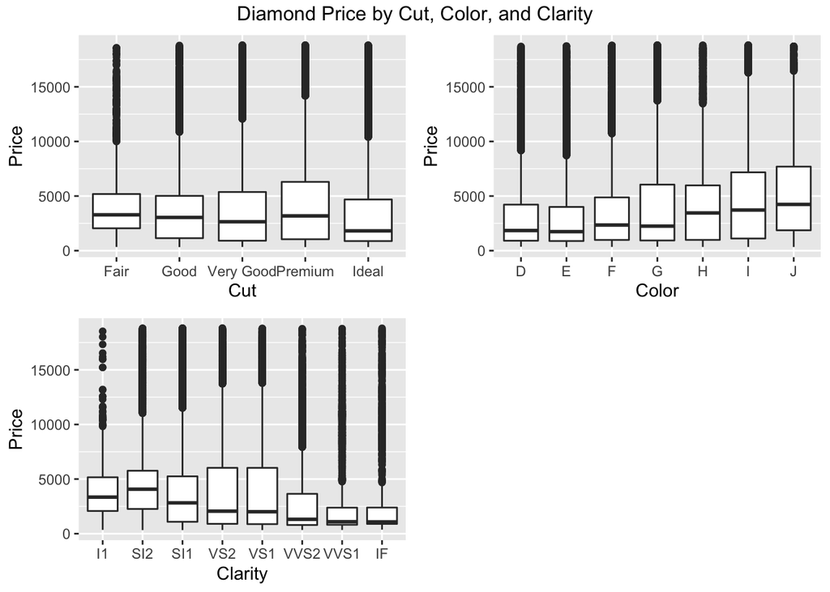

```r
# Create three separate box plots for categorical variables, horizontally aligned with title
plot1 <- ggplot(diamonds, aes(x = cut, y = price)) +
  geom_boxplot() +
  labs(x = "Cut", y = "Price")

plot2 <- ggplot(diamonds, aes(x = color, y = price)) +
  geom_boxplot() +
  labs(x = "Color", y = "Price")

plot3 <- ggplot(diamonds, aes(x = clarity, y = price)) +
  geom_boxplot() +
  labs(x = "Clarity", y = "Price")

# Combine the plots horizontally with a title
grid.arrange(plot1, plot2, plot3, ncol = 2, top = "Diamond Price by Cut, Color, and Clarity")
```

The box plots show the distribution of diamond prices for each level of the categorical variables: cut, color, and clarity.

To compare prices between categories, compare the position of the median on box plots. If one median is higher than the other, prices tend to be higher in that category. But, check the price range in each category for a complete view. For example, the first plot shows that diamonds with a “Ideal” cut tend to have lower prices compared to diamonds with a “Premium” cut, which have a wider range of prices. Similarly, the second plot shows that diamonds with a “E” color tend to have lower prices compared to diamonds with a “J” or “I” color, which have a wider range of prices. The third plot shows that diamonds with a “IF” clarity tend to have lower prices compared to diamonds with a “SI2” or “I1” clarity, which have a wider range of prices.

Outliers in box plots reveal diamonds with significantly higher or lower prices than the majority. They offer insights into factors beyond the primary characteristics that are used to evaluate and price diamonds, such as unique cuts or rare hues. The presence of outliers also underscores the importance of looking at the full range of prices within each category, rather than just focusing on the median or other summary statistics. Examining outliers is important for understanding diamond prices and making informed buying/selling decisions.

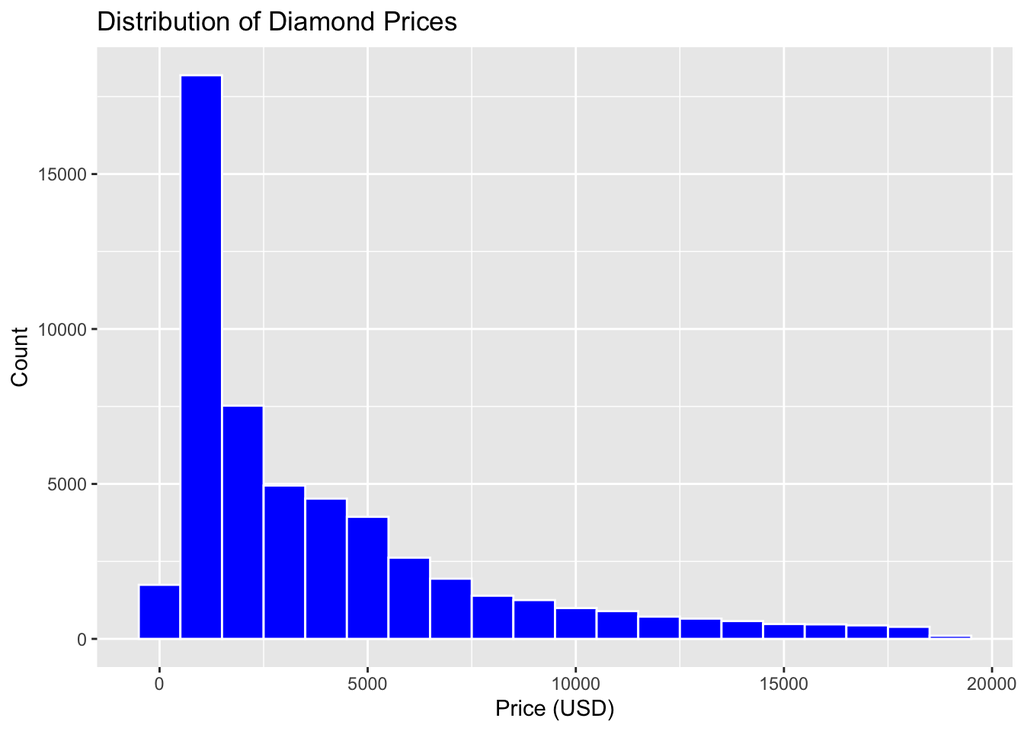

```r
ggplot(diamonds, aes(x = price)) +
  geom_histogram(binwidth = 1000, fill = "blue", color = "white") +
  labs(title = "Distribution of Diamond Prices",
       x = "Price (USD)", y = "Count")
```

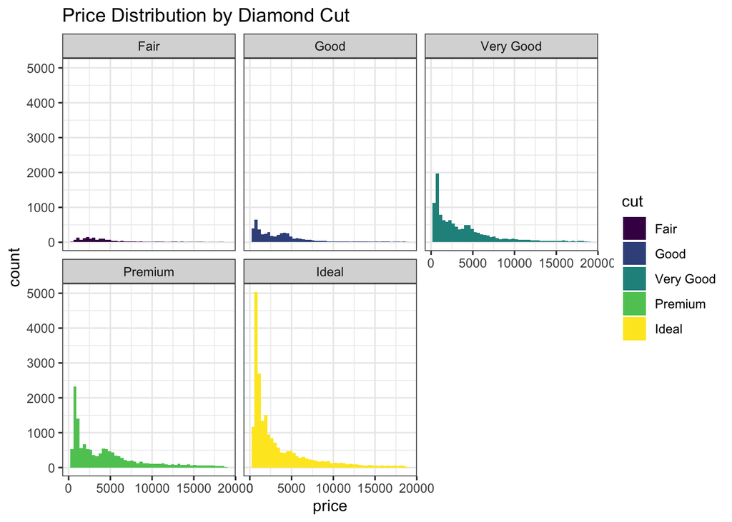

```r
# plot histogram of price by cut
ggplot(diamonds, aes(x = price, fill = cut)) +
  geom_histogram(bins = 50) +
  facet_wrap(~cut) +
  theme_bw() +
  labs(title = "Price Distribution by Diamond Cut")
```

#### Conclusion

The report delves into the diamond dataset by examining its structure, visualizing the distribution of numerical variables, and analyzing their relationships through a scatterplot matrix. It also investigates the connections between categorical variables and diamond prices. To clean the data, the report identifies and handles any duplicate records while locating outliers. We can use techniques like Trimming, Winsorizing, Capping, Imputation, and Robust statistics to address outliers in this dataset, which may need further study.

The data also proved to be quite intriguing as it underscored the significance of examining subsets of the information to pinpoint any potential outliers or anomalies prior to embarking on further analyses or modeling. To explain, the scatterplot matrix for the entire dataset was cluttered and difficult to interpret, whereas the scatterplot matrix for the randomly selected subset of data was more interpretable and showed clearer trends. This difference could be attributed to the presence of outliers that can skew statistical analyses and hinder the ability to draw meaningful conclusions from the data.

As next steps, we could consider delving deeper into our analysis by using regression analysis to examine the relationship between price and various variables. Specifically, we could explore how diamond carat weight affects price, and whether this relationship is linear or nonlinear.

#### References

Aggarwal, C. C. (2017). *Outlier analysis* (Second edition.). Springer. https://doi.org/10.1007/978-3-319-47578-3

Chen, C., Härdle, W., & Unwin, A. (2007). *Handbook of data visualization.* Springer.

*GGPLOT2 / R / data.R.* GitHub. (2022, March 15). Retrieved February 28, 2023, from https://github.com/tidyverse/ggplot2/blob/HEAD/R/data.R

Kabacoff, R. (2015). *R in action: data analysis and graphics with R* (Second edition.). Manning Publications.